# Real-world Data Wrangling

In this project, you will apply the skills you acquired in the course to gather and wrangle real-world data with two datasets of your choice.

You will retrieve and extract the data, assess the data programmatically and visually, accross elements of data quality and structure, and implement a cleaning strategy for the data. You will then store the updated data into your selected database/data store, combine the data, and answer a research question with the datasets.

Throughout the process, you are expected to:

1. Explain your decisions towards methods used for gathering, assessing, cleaning, storing, and answering the research question
2. Write code comments so your code is more readable

Before you start, install the some of the required packages.

```python
!python -m pip install kaggle==1.6.12
```

[output not shown]

```python
!pip install --target=/workspace ucimlrepo numpy==1.24.3
```

[output not shown]

**Note:** Restart the kernel to use updated package(s).

## 1. Gather data

In this section, you will extract data using two different data gathering methods and combine the data. Use at least two different types of data-gathering methods.

### **1.1.** Problem Statement

In 2-4 sentences, explain the kind of problem you want to look at and the datasets you will be wrangling for this project.

Finding the right datasets can be time-consuming. Here we provide you with a list of websites to start with. But we encourage you to explore more websites and find the data that interests you.

- Google Dataset Search https://datasetsearch.research.google.com/
- The U.S. Government’s open data https://data.gov/
- UCI Machine Learning Repository https://archive.ics.uci.edu/ml/index.php

**Through the process of assessing and cleaning the data of these covid-19 cases and vaccine, i want to see if there was a direct reason for getting vaccinated or was it just a global trend that most people followed with.**

### **1.2.** Gather at least two datasets using two different data gathering methods

List of data gathering methods:

- Download data manually
- Programmatically downloading files
- Gather data by accessing APIs
- Gather and extract data from HTML files using BeautifulSoup
- Extract data from a SQL database

Each dataset must have at least two variables, and have greater than 500 data samples within each dataset.

For each dataset, briefly describe why you picked the dataset and the gathering method (2-3 full sentences), including the names and significance of the variables in the dataset. Show your work (e.g., if using an API to download the data, please include a snippet of your code).

Load the dataset programmtically into this notebook.

#### **Dataset 1**

Type: "WHO_COVID-19_cases.csv"

Method: This dataset was gathered manually through downloading the csv file from kaggle and uploading it in the notebook. This dataset was gathered by WHO (world health organization ).

Dataset variables:

- Variable 1 Date_reported
- Variable 2 Country_code
- Variable 3 Country
- Variable 4 Continent
- Variable 5 WHO_region
- Variable 6 New_cases
- Variable 7 Cumulative_cases
- Variable 8 New_deaths
- Variable 9 Cumulative_deaths

```python
# importing libraries that will be used in this project, and for downloading the files
import numpy as np
import pandas as pd
```

```python
#FILL IN 1st data gathering and loading method
cases_raw = pd.read_csv("Datasets/WHO_COVID-19_cases.csv")
cases_raw.head(10)
```

|  | Date_reported | Country_code | Country | Continent | WHO_region | New_cases | Cumulative_cases | New_deaths | Cumulative_deaths |
| --- | --- | --- | --- | --- | --- | --- | --- | --- | --- |
| 0 | 2020-01-05 | AF | Afghanistan | Asia | EMRO | NaN | 0 | NaN | 0 |
| 1 | 2020-01-12 | AF | Afghanistan | Asia | EMRO | NaN | 0 | NaN | 0 |
| 2 | 2020-01-19 | AF | Afghanistan | Asia | EMRO | NaN | 0 | NaN | 0 |
| 3 | 2020-01-26 | AF | Afghanistan | Asia | EMRO | NaN | 0 | NaN | 0 |
| 4 | 2020-02-02 | AF | Afghanistan | Asia | EMRO | NaN | 0 | NaN | 0 |
| 5 | 2020-02-09 | AF | Afghanistan | Asia | EMRO | NaN | 0 | NaN | 0 |
| 6 | 2020-02-16 | AF | Afghanistan | Asia | EMRO | NaN | 0 | NaN | 0 |
| 7 | 2020-02-23 | AF | Afghanistan | Asia | EMRO | NaN | 0 | NaN | 0 |
| 8 | 2020-03-01 | AF | Afghanistan | Asia | EMRO | 1.0 | 1 | NaN | 0 |
| 9 | 2020-03-08 | AF | Afghanistan | Asia | EMRO | NaN | 1 | NaN | 0 |

#### Dataset 2

Type: "country_vaccinations_by_manufacturer.csv"

Link : https://www.kaggle.com/datasets/gpreda/covid-world-vaccination-progress

Dataset variables:

- *Variable 1 location (location of the vaccination)
- *Variable 2 date (date of vaccination)
- *Variable 3 vaccine (type of vaccine eg. Moderna)
- *Variable 4 total_vaccinations

```python
#FILL IN 2nd data gathering and loading method
!~/.local/bin/kaggle datasets download -d gpreda/covid-world-vaccination-progress -p ./Datasets --unzip
```

```
/usr/bin/sh: 1: /home/student/.local/bin/kaggle: not found
```

Optional data storing step: You may save your raw dataset files to the local data store before moving to the next step.

```python
#Optional: store the raw data in your local data store
vac_raw = pd.read_csv("Datasets/country_vaccinations_by_manufacturer.csv")
vac_raw.head(10)
```

|  | location | date | vaccine | total_vaccinations |
| --- | --- | --- | --- | --- |
| 0 | Argentina | 2020-12-29 | Moderna | 2 |
| 1 | Argentina | 2020-12-29 | Oxford/AstraZeneca | 3 |
| 2 | Argentina | 2020-12-29 | Sinopharm/Beijing | 1 |
| 3 | Argentina | 2020-12-29 | Sputnik V | 20481 |
| 4 | Argentina | 2020-12-30 | Moderna | 2 |
| 5 | Argentina | 2020-12-30 | Oxford/AstraZeneca | 3 |
| 6 | Argentina | 2020-12-30 | Sinopharm/Beijing | 1 |
| 7 | Argentina | 2020-12-30 | Sputnik V | 40583 |
| 8 | Argentina | 2020-12-31 | Moderna | 2 |
| 9 | Argentina | 2020-12-31 | Oxford/AstraZeneca | 3 |

## 2. Assess data

Assess the data according to data quality and tidiness metrics using the report below.

List **two** data quality issues and **two** tidiness issues. Assess each data issue visually **and** programmatically, then briefly describe the issue you find. **Make sure you include justifications for the methods you use for the assessment.**

### Quality Issue 1:

```python
#FILL IN - Inspecting the dataframe visually
cases_raw.sample(10)
```

|  | Date_reported | Country_code | Country | Continent | WHO_region | New_cases | Cumulative_cases | New_deaths | Cumulative_deaths |
| --- | --- | --- | --- | --- | --- | --- | --- | --- | --- |
| 5571 | 2023-11-26 | BM | Bermuda | North America | AMRO | NaN | 18860 | NaN | 165 |
| 51058 | 2021-03-14 | SE | Sweden | Europe | EURO | 28966.0 | 721351 | 136.0 | 13269 |
| 12722 | 2020-08-30 | CY | Cyprus | Europe | EURO | 66.0 | 1483 | NaN | 21 |
| 34251 | 2021-10-03 | MX | Mexico | North America | AMRO | 44758.0 | 3737172 | 2863.0 | 288288 |
| 8365 | 2021-05-02 | CV | Cabo Verde | Africa | AFRO | 2033.0 | 24127 | 19.0 | 220 |
| 2729 | 2020-11-15 | AU | Australia | Oceania | WPRO | 59.0 | 27711 | 3.0 | 917 |
| 1809 | 2021-12-12 | AG | Antigua and Barbuda | North America | AMRO | 12.0 | 4159 | NaN | 117 |
| 4912 | 2020-08-16 | BZ | Belize | North America | AMRO | 242.0 | 388 | 1.0 | 3 |
| 37782 | 2023-12-17 | NZ | New Zealand | Oceania | WPRO | 6136.0 | 2434052 | 27.0 | 3596 |
| 21019 | 2020-09-06 | GT | Guatemala | North America | AMRO | 3802.0 | 77481 | 117.0 | 2845 |

i'm noticing alot of NaN values in integer variables such "new cases" and "new deaths" columns.

```python
cases_raw.info()
```

```
<class 'pandas.core.frame.DataFrame'>
RangeIndex: 58560 entries, 0 to 58559
Data columns (total 9 columns):
 #   Column             Non-Null Count  Dtype
---  ------             --------------  -----
 0   Date_reported      58560 non-null  object
 1   Country_code       58316 non-null  object
 2   Country            58560 non-null  object
 3   Continent          58560 non-null  object
 4   WHO_region         54168 non-null  object
 5   New_cases          39260 non-null  float64
 6   Cumulative_cases   58560 non-null  int64
 7   New_deaths         25084 non-null  float64
 8   Cumulative_deaths  58560 non-null  int64
dtypes: float64(2), int64(2), object(5)
memory usage: 4.0+ MB
```

**Issue and justification: We took a look at a random sample of the data frame using .sample() and .info() and noticed that "new deaths" and "new cases" columns have alot of NaN values which probably means the value is 0, changing it into an integer/float value would be better for the analysis.**

### Quality Issue 2:

```python
#FILL IN - Inspecting the dataframe visually
cases_raw.info()
```

```
<class 'pandas.core.frame.DataFrame'>
RangeIndex: 58560 entries, 0 to 58559
Data columns (total 9 columns):
 #   Column             Non-Null Count  Dtype
---  ------             --------------  -----
 0   Date_reported      58560 non-null  object
 1   Country_code       58316 non-null  object
 2   Country            58560 non-null  object
 3   Continent          58560 non-null  object
 4   WHO_region         54168 non-null  object
 5   New_cases          39260 non-null  float64
 6   Cumulative_cases   58560 non-null  int64
 7   New_deaths         25084 non-null  float64
 8   Cumulative_deaths  58560 non-null  int64
dtypes: float64(2), int64(2), object(5)
memory usage: 4.0+ MB
```

"Date reported" column has a datatype of object, now let's check if the date's data type in the vaccine df is in correct form

```python
#FILL IN - Inspecting the dataframe programmatically
vac_raw.info()
```

```
<class 'pandas.core.frame.DataFrame'>
RangeIndex: 35623 entries, 0 to 35622
Data columns (total 4 columns):
 #   Column              Non-Null Count  Dtype
---  ------              --------------  -----
 0   location            35623 non-null  object
 1   date                35623 non-null  object
 2   vaccine             35623 non-null  object
 3   total_vaccinations  35623 non-null  int64
dtypes: int64(1), object(3)
memory usage: 1.1+ MB
```

**Issue and justification: We noticed that data types for date are inaccurate for both dataframes, we reached into that conclusion by using .info()**

### Quality issue 3:

```python
#FILL IN - Inspecting the dataframe visually
cases_raw.describe()
```

|  | New_cases | Cumulative_cases | New_deaths | Cumulative_deaths |
| --- | --- | --- | --- | --- |
| count | 3.926000e+04 | 5.856000e+04 | 25084.000000 | 5.856000e+04 |
| mean | 1.976918e+04 | 1.810312e+06 | 281.507335 | 2.012550e+04 |
| std | 2.699850e+05 | 7.851277e+06 | 1212.511007 | 8.220948e+04 |
| min | -6.507900e+04 | 0.000000e+00 | -3432.000000 | 0.000000e+00 |
| 25% | 4.200000e+01 | 4.402750e+03 | 4.000000 | 2.900000e+01 |
| 50% | 3.900000e+02 | 4.682750e+04 | 20.000000 | 5.845000e+02 |
| 75% | 3.925000e+03 | 5.351678e+05 | 104.000000 | 7.118000e+03 |
| max | 4.047548e+07 | 1.034368e+08 | 47687.000000 | 1.197213e+06 |

```python
deaths = cases_raw.loc[(cases_raw['New_deaths'] < 0)]
deaths['New_deaths'].info()
```

```
<class 'pandas.core.series.Series'>
Index: 13 entries, 2869 to 52018
Series name: New_deaths
Non-Null Count  Dtype
--------------  -----
13 non-null     float64
dtypes: float64(1)
memory usage: 208.0 bytes
```

```python
deaths = cases_raw.loc[(cases_raw['New_cases'] < 0)]
deaths['New_cases'].info()
```

```
<class 'pandas.core.series.Series'>
Index: 20 entries, 4998 to 58502
Series name: New_cases
Non-Null Count  Dtype
--------------  -----
20 non-null     float64
dtypes: float64(1)
memory usage: 320.0 bytes
```

**Issue and justification: We can notice that there are negative values in "new cases" and "new deaths" columns. Using .describe() and looking at the minimum value and then assuring by using the .loc[] method to spot the inaccurate data**

### Tidiness Issue 1:

```python
#FILL IN - Inspecting the dataframe visually
cases_raw.head()
```

|  | Date_reported | Country_code | Country | Continent | WHO_region | New_cases | Cumulative_cases | New_deaths | Cumulative_deaths |
| --- | --- | --- | --- | --- | --- | --- | --- | --- | --- |
| 0 | 2020-01-05 | AF | Afghanistan | Asia | EMRO | NaN | 0 | NaN | 0 |
| 1 | 2020-01-12 | AF | Afghanistan | Asia | EMRO | NaN | 0 | NaN | 0 |
| 2 | 2020-01-19 | AF | Afghanistan | Asia | EMRO | NaN | 0 | NaN | 0 |
| 3 | 2020-01-26 | AF | Afghanistan | Asia | EMRO | NaN | 0 | NaN | 0 |
| 4 | 2020-02-02 | AF | Afghanistan | Asia | EMRO | NaN | 0 | NaN | 0 |

```python
vac_raw.head()
```

|  | location | date | vaccine | total_vaccinations |
| --- | --- | --- | --- | --- |
| 0 | Argentina | 2020-12-29 | Moderna | 2 |
| 1 | Argentina | 2020-12-29 | Oxford/AstraZeneca | 3 |
| 2 | Argentina | 2020-12-29 | Sinopharm/Beijing | 1 |
| 3 | Argentina | 2020-12-29 | Sputnik V | 20481 |
| 4 | Argentina | 2020-12-30 | Moderna | 2 |

**Issue and justification: There are Inconsistencies in the column naming between the two datasets, in the "location" variable in the vaccination df and in "Date_reported" variable in the cases df**

### Tidiness Issue 2:

```python
#FILL IN - Inspecting the dataframe visually
vac_raw.head()
```

|  | location | date | vaccine | total_vaccinations |
| --- | --- | --- | --- | --- |
| 0 | Argentina | 2020-12-29 | Moderna | 2 |
| 1 | Argentina | 2020-12-29 | Oxford/AstraZeneca | 3 |
| 2 | Argentina | 2020-12-29 | Sinopharm/Beijing | 1 |
| 3 | Argentina | 2020-12-29 | Sputnik V | 20481 |
| 4 | Argentina | 2020-12-30 | Moderna | 2 |

```python
#FILL IN - Inspecting the dataframe programmatically
vac_raw.tail()
```

|  | location | date | vaccine | total_vaccinations |
| --- | --- | --- | --- | --- |
| 35618 | European Union | 2022-03-29 | Oxford/AstraZeneca | 67403106 |
| 35619 | European Union | 2022-03-29 | Pfizer/BioNTech | 600519998 |
| 35620 | European Union | 2022-03-29 | Sinopharm/Beijing | 2301516 |
| 35621 | European Union | 2022-03-29 | Sinovac | 1809 |
| 35622 | European Union | 2022-03-29 | Sputnik V | 1845103 |

**Issue and justification: By seeing the head and the tail of the dataframe we can notice that the data is not aggregated properly, meaning that we have many rows for different vaccines**

## 3. Clean data

Clean the data to solve the 4 issues corresponding to data quality and tidiness found in the assessing step. **Make sure you include justifications for your cleaning decisions.**

After the cleaning for each issue, please use **either** the visually or programatical method to validate the cleaning was succesful.

At this stage, you are also expected to remove variables that are unnecessary for your analysis and combine your datasets. Depending on your datasets, you may choose to perform variable combination and elimination before or after the cleaning stage. Your dataset must have **at least** 4 variables after combining the data.

```python
# FILL IN - Make copies of the datasets to ensure the raw dataframes
# are not impacted
cases_cleaned = cases_raw.copy()
vac_cleaned = vac_raw.copy()
```

### **Quality Issue 1: Filling missing values**

```python
# FILL IN - Apply the cleaning strategy
cases_cleaned["New_cases"] = cases_raw["New_cases"].fillna(0)
cases_cleaned["New_deaths"] = cases_raw["New_deaths"].fillna(0)
```

```python
# FILL IN - Validate the cleaning was successful
cases_cleaned[["New_cases", "New_deaths"]].isna().sum()
```

```
New_cases     0
New_deaths    0
dtype: int64
```

Justification: I used the .fillna() method to replace null values with zero.

### **Quality Issue 2: Adjusting Data types**

```python
#FILL IN - Apply the cleaning strategy
cases_cleaned['Date_reported'] = pd.to_datetime(cases_cleaned['Date_reported'])
vac_cleaned['date'] = pd.to_datetime(vac_cleaned['date'])
```

```python
#FILL IN - Validate the cleaning was successful
print(cases_cleaned["Date_reported"].dtype)
print(vac_cleaned["date"].dtype)
```

```
datetime64[ns]
datetime64[ns]
```

Justification: Changed the data type of date to datetime using "pd.to_datetime" and assured that using .dtype.

### **Quality Issue 3: Dropping negative values in non-negative variable**

```python
#FILL IN - Apply the cleaning strategy
cases_cleaned = cases_cleaned.loc[cases_cleaned['New_cases'] >= 0]
cases_cleaned = cases_cleaned.loc[cases_cleaned['New_deaths'] >= 0]
```

```python
cases_cleaned.describe()
```

|  | Date_reported | New_cases | Cumulative_cases | New_deaths | Cumulative_deaths |
| --- | --- | --- | --- | --- | --- |
| count | 58527 | 5.852700e+04 | 5.852700e+04 | 58527.000000 | 5.852700e+04 |
| mean | 2022-05-04 10:59:38.040903936 | 1.326147e+04 | 1.809061e+06 | 120.647633 | 2.012818e+04 |
| min | 2020-01-05 00:00:00 | 0.000000e+00 | 0.000000e+00 | 0.000000 | 0.000000e+00 |
| 25% | 2021-03-07 00:00:00 | 0.000000e+00 | 4.402500e+03 | 0.000000 | 2.900000e+01 |
| 50% | 2022-05-01 00:00:00 | 4.400000e+01 | 4.682900e+04 | 0.000000 | 5.850000e+02 |
| 75% | 2023-07-02 00:00:00 | 1.202000e+03 | 5.353500e+05 | 12.000000 | 7.118000e+03 |
| max | 2024-09-01 00:00:00 | 4.047548e+07 | 1.034368e+08 | 47687.000000 | 1.197213e+06 |
| std | NaN | 2.213183e+05 | 7.842895e+06 | 805.606338 | 8.222801e+04 |

Justification: We dropped negative values in columns that don't take negative values using .loc[] to filter the negative values.

### **Tidiness Issue 1: Inconsistencies in column naming**

```python
#FILL IN - Apply the cleaning strategy
cases_cleaned.rename(columns={"Date_reported": "date"}, inplace=True)
vac_cleaned.rename(columns={"location": "Country"}, inplace=True)
```

```python
#FILL IN - Validate the cleaning was successful
vac_cleaned.head(1)
```

|  | Country | date | vaccine | total_vaccinations |
| --- | --- | --- | --- | --- |
| 0 | Argentina | 2020-12-29 | Moderna | 2 |

```python
cases_cleaned.head(1)
```

|  | date | Country_code | Country | Continent | WHO_region | New_cases | Cumulative_cases | New_deaths | Cumulative_deaths |
| --- | --- | --- | --- | --- | --- | --- | --- | --- | --- |
| 0 | 2020-01-05 | AF | Afghanistan | Asia | EMRO | 0.0 | 0 | 0.0 | 0 |

Justification: We made the columns naming matching in both columns using .rename() method.

### **Tidiness Issue 2: Reshaping the data**

```python
#FILL IN - Apply the cleaning strategy
vac_cleaned = vac_cleaned.pivot_table(index=['Country', 'date'],
                                               columns='vaccine',
                                               values='total_vaccinations',
                                               fill_value=0).reset_index()
```

```python
#FILL IN - Validate the cleaning was successful
vac_cleaned.head()
```

| vaccine | Country | date | CanSino | Covaxin | Johnson&Johnson | Moderna | Novavax | Oxford/AstraZeneca | Pfizer/BioNTech | Sinopharm/Beijing | Sinovac | Sputnik V |
| --- | --- | --- | --- | --- | --- | --- | --- | --- | --- | --- | --- | --- |
| 0 | Argentina | 2020-12-29 | 0.0 | 0.0 | 0.0 | 2.0 | 0.0 | 3.0 | 0.0 | 1.0 | 0.0 | 20481.0 |
| 1 | Argentina | 2020-12-30 | 0.0 | 0.0 | 0.0 | 2.0 | 0.0 | 3.0 | 0.0 | 1.0 | 0.0 | 40583.0 |
| 2 | Argentina | 2020-12-31 | 0.0 | 0.0 | 0.0 | 2.0 | 0.0 | 3.0 | 0.0 | 1.0 | 0.0 | 43388.0 |
| 3 | Argentina | 2021-01-01 | 0.0 | 0.0 | 0.0 | 2.0 | 0.0 | 5.0 | 0.0 | 1.0 | 0.0 | 43513.0 |
| 4 | Argentina | 2021-01-02 | 0.0 | 0.0 | 0.0 | 2.0 | 0.0 | 6.0 | 0.0 | 1.0 | 0.0 | 46824.0 |

### **Remove unnecessary variables and combine datasets**

Depending on the datasets, you can also peform the combination before the cleaning steps.

```python
#FILL IN - Remove unnecessary variables and combine datasets
# We can also drop Country_code and WHO_region since they wont help with the analysis
cases_cleaned.drop(columns =['Country_code', 'WHO_region'], inplace = True )
merged_df = cases_cleaned.merge(vac_cleaned, on=["Country", "date"], how="inner")
merged_df.head(10)
```

|  | date | Country | Continent | New_cases | Cumulative_cases | New_deaths | Cumulative_deaths | CanSino | Covaxin | Johnson&Johnson | Moderna | Novavax | Oxford/AstraZeneca | Pfizer/BioNTech | Sinopharm/Beijing | Sinovac | Sputnik V |
| --- | --- | --- | --- | --- | --- | --- | --- | --- | --- | --- | --- | --- | --- | --- | --- | --- | --- |
| 0 | 2021-01-03 | Argentina | South America | 60464.0 | 1690372 | 1103.0 | 48610 | 0.0 | 0.0 | 0.0 | 2.0 | 0.0 | 6.0 | 0.0 | 1.0 | 0.0 | 47266.0 |
| 1 | 2021-01-10 | Argentina | South America | 84733.0 | 1775105 | 1415.0 | 50025 | 0.0 | 0.0 | 0.0 | 2.0 | 0.0 | 7.0 | 0.0 | 10.0 | 0.0 | 136034.0 |
| 2 | 2021-01-17 | Argentina | South America | 77946.0 | 1853051 | 1300.0 | 51325 | 0.0 | 0.0 | 0.0 | 2.0 | 0.0 | 8.0 | 0.0 | 19.0 | 0.0 | 233025.0 |
| 3 | 2021-01-24 | Argentina | South America | 79316.0 | 1932367 | 1260.0 | 52585 | 0.0 | 0.0 | 0.0 | 2.0 | 0.0 | 22.0 | 0.0 | 23.0 | 0.0 | 303080.0 |
| 4 | 2021-01-31 | Argentina | South America | 61185.0 | 1993552 | 1131.0 | 53716 | 0.0 | 0.0 | 0.0 | 2.0 | 0.0 | 71.0 | 0.0 | 25.0 | 0.0 | 389626.0 |
| 5 | 2021-02-07 | Argentina | South America | 51269.0 | 2044821 | 948.0 | 54664 | 3.0 | 0.0 | 0.0 | 2.0 | 0.0 | 140.0 | 0.0 | 66.0 | 0.0 | 532955.0 |
| 6 | 2021-02-14 | Argentina | South America | 50744.0 | 2095565 | 935.0 | 55599 | 3.0 | 0.0 | 0.0 | 2.0 | 0.0 | 153.0 | 0.0 | 89.0 | 0.0 | 629016.0 |
| 7 | 2021-02-21 | Argentina | South America | 42687.0 | 2138252 | 797.0 | 56396 | 3.0 | 0.0 | 0.0 | 2.0 | 0.0 | 935.0 | 0.0 | 101.0 | 0.0 | 839697.0 |
| 8 | 2021-02-28 | Argentina | South America | 44701.0 | 2182953 | 831.0 | 57227 | 3.0 | 0.0 | 0.0 | 2.0 | 0.0 | 263527.0 | 0.0 | 121.0 | 0.0 | 1010370.0 |
| 9 | 2021-03-07 | Argentina | South America | 43723.0 | 2226676 | 884.0 | 58111 | 3.0 | 0.0 | 0.0 | 2.0 | 0.0 | 467234.0 | 0.0 | 203265.0 | 0.0 | 1115559.0 |

## 4. Update your data store

Update your local database/data store with the cleaned data, following best practices for storing your cleaned data:

- Must maintain different instances / versions of data (raw and cleaned data)
- Must name the dataset files informatively
- Ensure both the raw and cleaned data is saved to your database/data store

```python
#FILL IN - saving data
merged_df.to_csv("Datasets/cleaned_data.csv", index=False)
cases_cleaned.to_csv("Datasets/cases_cleaned.csv", index = False)
vac_cleaned.to_csv("Datasets/vac_cleaned.csv", index = False)
```

## 5. Answer the research question

### **5.1:** Define and answer the research question

Going back to the problem statement in step 1, use the cleaned data to answer the question you raised. Produce **at least** two visualizations using the cleaned data and explain how they help you answer the question.

*Research question:* Did people across the world realize that covid-19 is dangerous and not some kind of conspiracy and started getting vaccinated or once people set their mind into something then it doesn't change.

**Did "Cumulative_deaths" affect "total_vaccinations" accross time?**

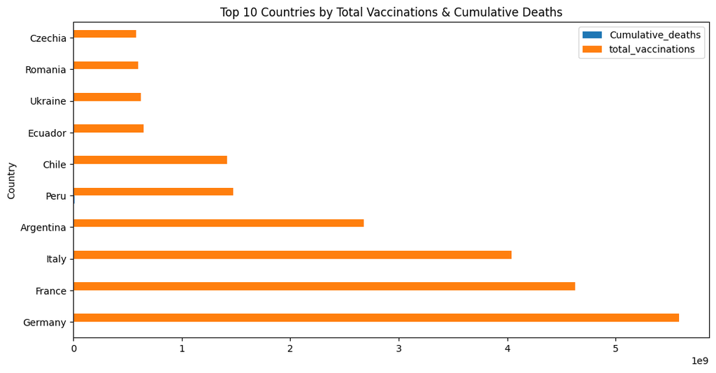

```python
#Visual 1 - FILL IN
# we are gonna add a column named total vaccinations to help in the analysis

merged_df['total_vaccinations'] = merged_df.iloc[:, 7:].sum(axis=1)

df_country = merged_df.groupby("Country")[["Cumulative_deaths", "total_vaccinations"]].sum()

df_top_countries = df_country.sort_values("total_vaccinations", ascending=False).head(10)

df_top_countries.plot(kind="barh", figsize=(12,6), title="Top 10 Countries by Total Vaccinations & Cumulative Deaths")
```

*Answer to research question:* Based on the bar chart above, which shows top 10 countries in individuals gettin vaccinated, it looks like the total vaccinations had nothing to do with the deaths and the people were getting vaccines either for official doccumentation or to be stay safe from the virus.

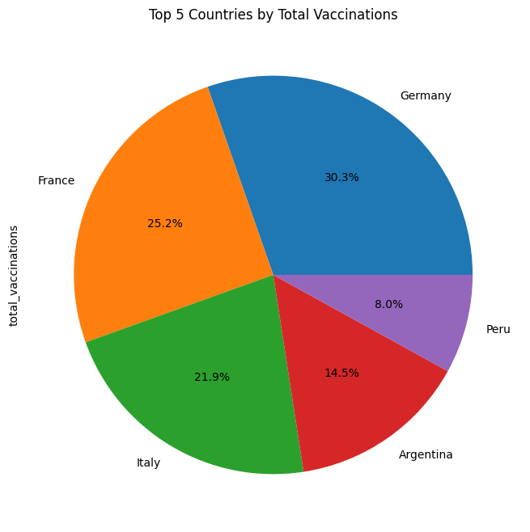

```python
#Visual 2 - FILL IN
df_country_vax = merged_df.groupby("Country")["total_vaccinations"].sum()

df_top_countries_vax = df_country_vax.sort_values(ascending=False).head(5)

df_top_countries_vax.plot(kind="pie", autopct='%1.1f%%', figsize=(8,8), title="Top 5 Countries by Total Vaccinations")
```

```python
top_5_countries_deaths = merged_df.groupby("Country")["Cumulative_deaths"].max().sort_values(ascending=False).head(5)

print(top_5_countries_deaths)
```

```
Country
Peru         211751
Italy        158700
France       142547
Germany      136107
Argentina    128299
Name: Cumulative_deaths, dtype: int64
```

**To understand the piechart above more, we listed the top 5 countries with the most deaths. We can notice that they are the same with the most total vaccinations**

*Answer to research question:* In the second visual we can notice that countries with most deaths has the most total vaccinations, which is against the results of the last visualization. But in my opinion i do believe the second inspection more, because people seeing relatives and friends die from covid-19 raised awareness among the world

### **5.2:** Reflection

In 2-4 sentences, if you had more time to complete the project, what actions would you take? For example, which data quality and structural issues would you look into further, and what research questions would you further explore?

*Answer:* I would probably fix the vaccine - total_vaccinations relation more, maybe by melting the columns. I would sum the total vaccinations in a specific date to show the total in that country not just the vaccine.